# GLOBAL TERRORISM DATABASE

## Instructions:

1. Download data set, Global Terrorism Database, from https://www.kaggle.com/START-UMD/gtd
2. Take a quick look at the data set. Check what's inside, how the data is structured, and where the data is corrupted (missing values, bad structure, etc).
3. Think and create 5 questions to the data. Try to ask yourself what's really interesting in the data set. What's not so obvious. E.g. some trends, patterns, correlations.
4. Create a jupyter notebook and use python, numpy, pandas, matplotlib (at least) to provide all the answers to your questions.
5. Create a new github repository, and put your jupyter notebook there.
6. Create readme.md file as well in your github root directory with all necessary instructions (what is in the repo, what libs are necessary to run the code, where to find data set and where to save it - this is necessary because the dataset is too big for github repo).
7. Provide the necessary documentation and introduction in your notebook using markdown language, at least: data source description, data structure, importing process, data processing process.
8. Put some data visualization in your notebook. Sometimes it's much easier to present the answer using a chart rather than numbers
9. Check if your notebook run smoothly - use 'Reset & Run All' command from the menu. Save it.
10. Export the notebook as HTML as well, and save the file in the repo.
11. Do not forget to commit/push all the changes to your repo on hithub.
12. Smile :) You did a good job!

FAQ:

1. Can I take a look at different solution provided at kaggle? Yes, you can. But check more than one solution. Try to understand what the authors are trying to solve, and how could it be used in your project. Try to find really good examples - easy to understand and not so complicated. Remember - you create the notebook as an instruction to someone else! Try to not complicate the process.
2. Can I take a look at my friend's solution, that he/she has just put on github? Yes, you can. But it's the smart way of solving the project. I'm sure that you want to be smarter in the next semester - so try to create a better solution and your own one :)
3. Jupyter notebook provide R kernel, so can I use R instead? Nope, R sucks. Even if you love R, try to solve the project using Python.

## Read the file

```python
import csv
import numpy as np
import matplotlib.pyplot as plt
import pandas as pd
import seaborn as sns
```

```python
data = pd.read_csv('globalterrorismdb_0718dist.csv', encoding='ISO-8859-1')
data.head()
```

|  | eventid | iyear | imonth | iday | approxdate | extended | resolution | country | country_txt | region | ... | addnotes | scite1 | scite2 | scite3 | dbsource | INT_LOG | INT_IDEO | INT_MISC | INT_ANY | related |
| --- | --- | --- | --- | --- | --- | --- | --- | --- | --- | --- | --- | --- | --- | --- | --- | --- | --- | --- | --- | --- | --- |
| 0 | 197000000001 | 1970 | 7 | 2 | NaN | 0 | NaN | 58 | Dominican Republic | 2 | ... | NaN | NaN | NaN | NaN | PGIS | 0 | 0 | 0 | 0 | NaN |
| 1 | 197000000002 | 1970 | 0 | 0 | NaN | 0 | NaN | 130 | Mexico | 1 | ... | NaN | NaN | NaN | NaN | PGIS | 0 | 1 | 1 | 1 | NaN |
| 2 | 197001000001 | 1970 | 1 | 0 | NaN | 0 | NaN | 160 | Philippines | 5 | ... | NaN | NaN | NaN | NaN | PGIS | -9 | -9 | 1 | 1 | NaN |
| 3 | 197001000002 | 1970 | 1 | 0 | NaN | 0 | NaN | 78 | Greece | 8 | ... | NaN | NaN | NaN | NaN | PGIS | -9 | -9 | 1 | 1 | NaN |
| 4 | 197001000003 | 1970 | 1 | 0 | NaN | 0 | NaN | 101 | Japan | 4 | ... | NaN | NaN | NaN | NaN | PGIS | -9 | -9 | 1 | 1 | NaN |

5 rows × 135 columns

# Is there any correlation between variables?

```python
#data['extended'].corr(data['attacktype1'])
corr = data.corr(method='spearman')
```

```python
s = corr.unstack().abs()
so = s.sort_values(kind="quicksort")
so=so[(so>0.55)&(so<0.99)]
print(so)
```

```
nhours        ransompaid      0.551418
ransompaid    nhours          0.551418
nhours        eventid         0.552413
eventid       nhours          0.552413
attacktype2   weapsubtype2    0.554009
weapsubtype2  attacktype2     0.554009
weaptype4     nreleased       0.555492
nreleased     weaptype4       0.555492
claimmode2    claimmode       0.562068
claimmode     claimmode2      0.562068
weapsubtype1  attacktype1     0.562660
attacktype1   weapsubtype1    0.562660
attacktype3   ransompaid      0.578638
ransompaid    attacktype3     0.578638
longitude     propvalue       0.579707
propvalue     longitude       0.579707
attacktype3   attacktype2     0.580971
attacktype2   attacktype3     0.580971
nwoundte      weaptype4       0.592927
weaptype4     nwoundte        0.592927
claimmode3    nhostkidus      0.600000
nhostkidus    claimmode3      0.600000
guncertain1   guncertain2     0.601330
guncertain2   guncertain1     0.601330
guncertain3   guncertain2     0.602797
guncertain2   guncertain3     0.602797
weaptype2     attacktype2     0.608658
attacktype2   weaptype2       0.608658
nkillter      suicide         0.611731
suicide       nkillter        0.611731
                                ...
nreleased     claimmode3      0.800000
claimmode3    nreleased       0.800000
ransompaid    claimmode2      0.816497
claimmode2    ransompaid      0.816497
INT_IDEO      INT_ANY         0.833518
INT_ANY       INT_IDEO        0.833518
ransomamt     weapsubtype4    0.866025
weapsubtype4  ransomamt       0.866025
country       natlty2         0.866749
natlty2       country         0.866749
country       natlty1         0.877725
natlty1       country         0.877725
weaptype1     weapsubtype1    0.879128
weapsubtype1  weaptype1       0.879128
crit3         alternative     0.883439
alternative   crit3           0.883439
weapsubtype4  weaptype4       0.921789
weaptype4     weapsubtype4    0.921789
weaptype3     weapsubtype3    0.932261
weapsubtype3  weaptype3       0.932261
weapsubtype2  weaptype2       0.939693
weaptype2     weapsubtype2    0.939693
targtype2     targsubtype2    0.940449
targsubtype2  targtype2       0.940449
targtype3     targsubtype3    0.947167
targsubtype3  targtype3       0.947167
INT_IDEO      INT_LOG         0.953905
INT_LOG       INT_IDEO        0.953905
targsubtype1  targtype1       0.983577
targtype1     targsubtype1    0.983577
Length: 104, dtype: float64
```

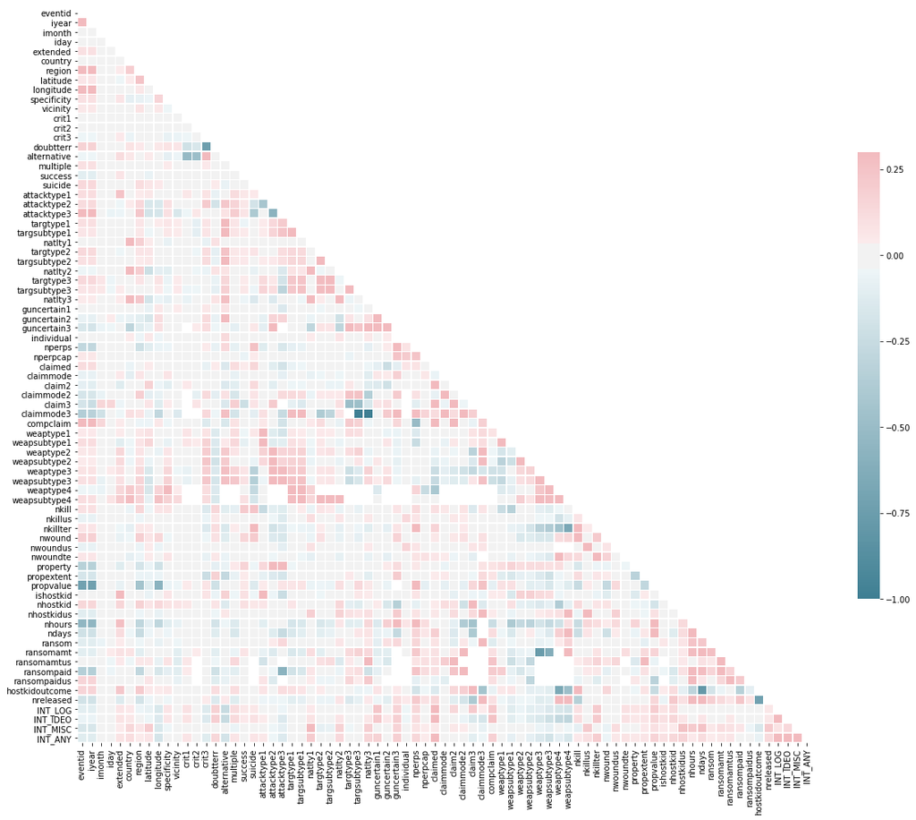

```python
mask = np.zeros_like(corr, dtype=np.bool)
mask[np.triu_indices_from(mask)] = True
# Set up the matplotlib figure
f, ax = plt.subplots(figsize=(20, 20))
# Generate a custom diverging colormap
cmap = sns.diverging_palette(220, 10, as_cmap=True)
# Draw the heatmap with the mask and correct aspect ratio
sns.heatmap(corr, mask=mask, cmap=cmap, vmax=.3, center=0,
            square=True, linewidths=.5, cbar_kws={"shrink": .5})
```

# Quality of data

```python
null_data=(data.isnull().mean() * 100).sort_values()
#print(nl.count())
print("Columns with more than 50% null data takes",round(null_data[null_data>50].count()/len(data.columns)*100,3),"% of number of all columns.")
```

```
Columns with more than 50% null data takes 57.037 % of number of all columns.
```

# What is the most attacked region?

```
Middle East & North Africa     50474
South Asia                     44974
South America                  18978
Sub-Saharan Africa             17550
Western Europe                 16639
Southeast Asia                 12485
Central America & Caribbean    10344
Eastern Europe                  5144
North America                   3456
East Asia                        802
Name: region_txt, dtype: int64
```

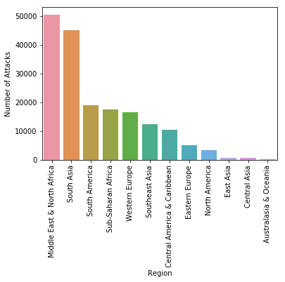

```python
no_region=data['region_txt'].value_counts(sort=True)
print(no_region.head(10))

p = sns.barplot(no_region.index,no_region)
p.set(xlabel="Region",ylabel="Number of Attacks")
p.set_xticklabels(no_region.index,rotation=90)
plt.show()
```

# What is the most attaked country?

```python
no_country=data['country_txt'].value_counts(sort=True)
no_country_10=no_country.head(10)
```

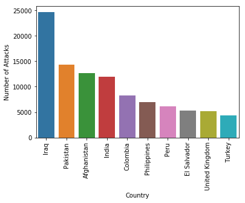

```python
p = sns.barplot(no_country_10.index,no_country_10)
p.set(xlabel="Country",ylabel="Number of Attacks")
p.set_xticklabels(no_country.index,rotation=90)
plt.show()
```

```python
no_country.max()
```

```
24636
```

# What is the trend in the attacked regions?

```python
no_year=data['iyear'].value_counts(sort=True)

#print(no_year.head(10))
no_year = pd.DataFrame(no_year)
data= pd.merge(data, no_year, how='left', on=None, left_on='iyear', right_on=no_year.index,
         left_index=False, right_index=False, sort=True,
         suffixes=('_x', '_y'), copy=True, indicator=False,
         validate=None)
```

```python
sns.set()
d = data.groupby(['region_txt','iyear'])['iyear'].count()
d = pd.DataFrame(d)
d.reset_index(level=0,inplace=True)
d.columns = ['Region','Number of Attacks']
d.reset_index(level=0,inplace=True)
```

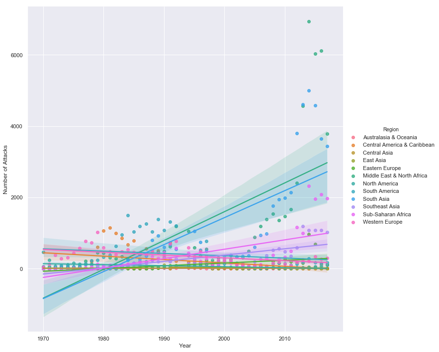

```python
sns.set()

g = sns.lmplot(x="iyear", y="Number of Attacks", hue="Region",
               truncate=True, height=10, data=d)
g.set_axis_labels("Year", "Number of Attacks")
```

# What is an impact of suicidal mission to number of killed and wounded people?

```python
sns.set()

g = data.groupby(['iyear', 'suicide'])['nkill'].sum()
d = pd.DataFrame(g)
d.reset_index(level=0,inplace=True)
d.columns = ['Year','Killed']
d.reset_index(level=0,inplace=True)


g2 = data.groupby(['iyear', 'suicide'])['nwound'].sum()
d2 = pd.DataFrame(g2)
d2.reset_index(level=0,inplace=True)
d2.columns = ['Year','Wounded']
d2.reset_index(level=0,inplace=True)
```

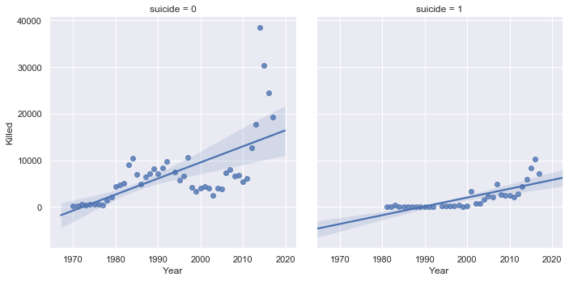

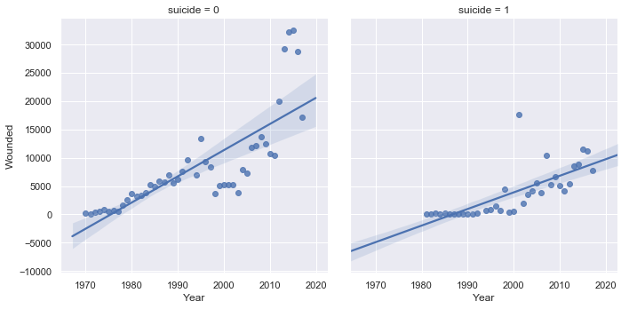

```python
#d = pd.DataFrame(d)

g=sns.lmplot(x="Year", y='Killed', col="suicide", data=d,
                y_jitter=.02,) #logistic=True)

g2=sns.lmplot(x="Year", y="Wounded", col="suicide", data=d2,
                y_jitter=.02,)# logistic=True)
```

## Killed and wounded by region

Big orange dot shows scale of the WTC attack on Sept 11 th 2001.

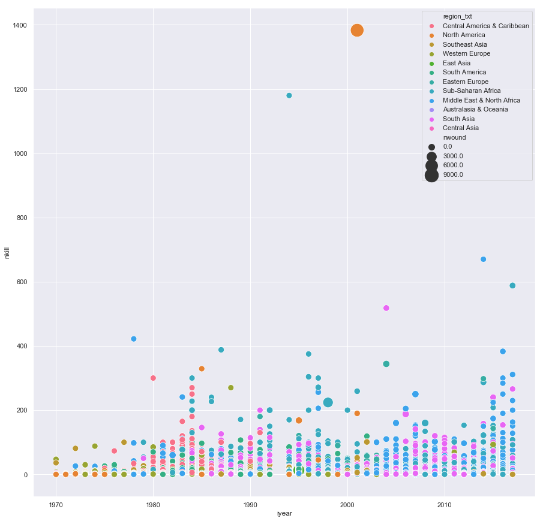

```python
sns.set()
f, ax = plt.subplots(figsize=(15, 15))
ax = sns.scatterplot(x="iyear", y="nkill",
                     hue="region_txt", size="nwound",
                     sizes=(100,500),
                    data=data)
```

# Which terrorist group is the most active in the most dangerous region?

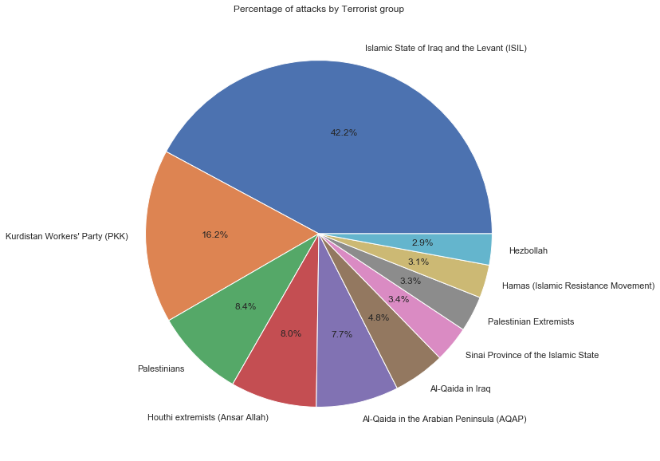

```python
plt.subplots(figsize=(10,10))
d = pd.DataFrame(data[data['gname']!="Unknown"][data['region_txt']=='Middle East & North Africa']['gname'].value_counts(sort=True)[:10])
d.reset_index(inplace=True)
d.columns=['Terrorist group','no_of_attacks']
#append = ['Other',sum(data['gname'].value_counts(sort=True)) - sum(data['gname'].value_counts(sort=True)[:10])]
#d.loc[len(d)]= append

plt.title("Percentage of attacks by Terrorist group")
plt.pie(d['no_of_attacks'],labels=d['Terrorist group'],autopct='%.1f%%')
plt.show()
```

# Which weapon is the mostly used in the most dangerous region?

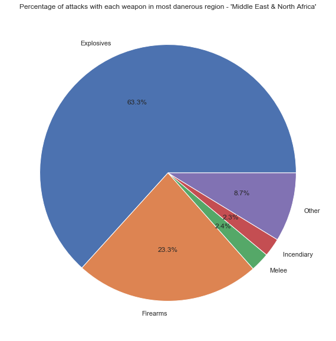

```python
plt.subplots(figsize=(10,10))
d = pd.DataFrame(data[data['region_txt']=='Middle East & North Africa'][data['weaptype1_txt']!="Unknown"]['weaptype1_txt'].value_counts(sort=True)[:4])
d.reset_index(inplace=True)
d.columns=['Weapon type','no_of_attacks']
append = ['Other',sum(data['weaptype1_txt'].value_counts(sort=True)) - sum(data['weaptype1_txt'].value_counts(sort=True)[:4])]
d.loc[len(d)]= append

plt.title("Percentage of attacks with each weapon in most danerous region - 'Middle East & North Africa'")
plt.pie(d['no_of_attacks'],labels=d['Weapon type'],autopct='%.1f%%')
plt.show()
```